# CodeThrough: Campaign Expenditures and Outcomes

Robert A. Jones

3/1/20

## Efficient Campaigns (a guide to finding more votes for your buck)

For this code through we’ll walk through voting data from the 1988 Congressional elections to look at the ways that campaign expenditures are correlated with the outcomes of those elections. The goal is to find which campaigns were run most efficiently in an effort to learn from their strategy. While this data won’t give the reasons that those campaigns were successful, it will tell us which campaigns to research.

While this data might feel outdated it is actually very useful. Using outdated or fake data to explain research methods gives validity to our outcomes when current data is inserted into the model.

We’ll start by loading a few packages and our data. We’ll also set our graph size to fill the page.

```r
library("tidyverse")
library("dplyr")
library("wooldridge")
library("huxtable")
library("corrplot")
library("Hmisc")
library("corrgram")
data(vote1)
knitr::opts_chunk$set(fig.height = 8.5, fig.width = 11)
```

The first graph we’ll load is a Correlogram. This will look for correlation throughout the variables in our dataset:

[figure not shown]

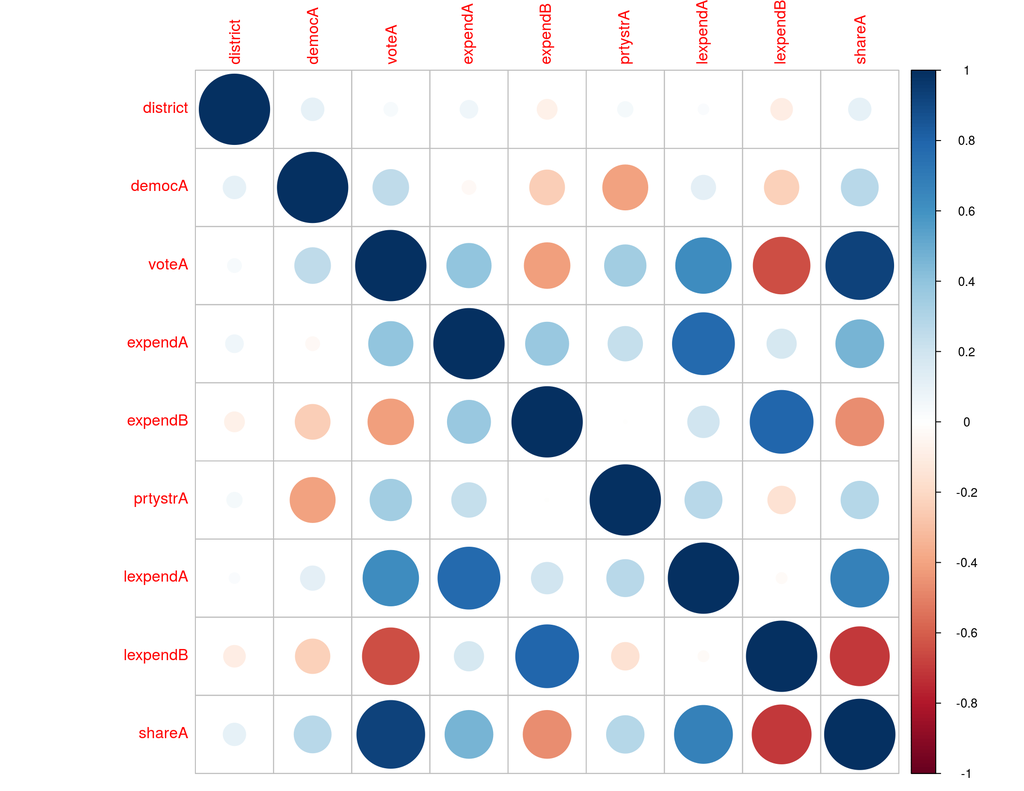

```r
corrplot(corrgram(vote1))
```

The correlogram shows us what we would generally expect. The percentage of votes received by a candidate has a strongly positive correlated to the percentage of total spending by that candidate, and a negative correlation to the percentage of total spending by the opposing candidate. However, this doesn’t necessarily help campaigns with fewer dollars to spend. Those candidates need to find the outliers, the campaigns that received more votes than would regularly be expected.

To zero in on those efficient campaigns, the one who found victory while having less to spend, we’ll have to drill down further on the data.

We’ll dive deeper by plotting the percentage of total expenditures by Candidate A against the percentage of the vote they received.

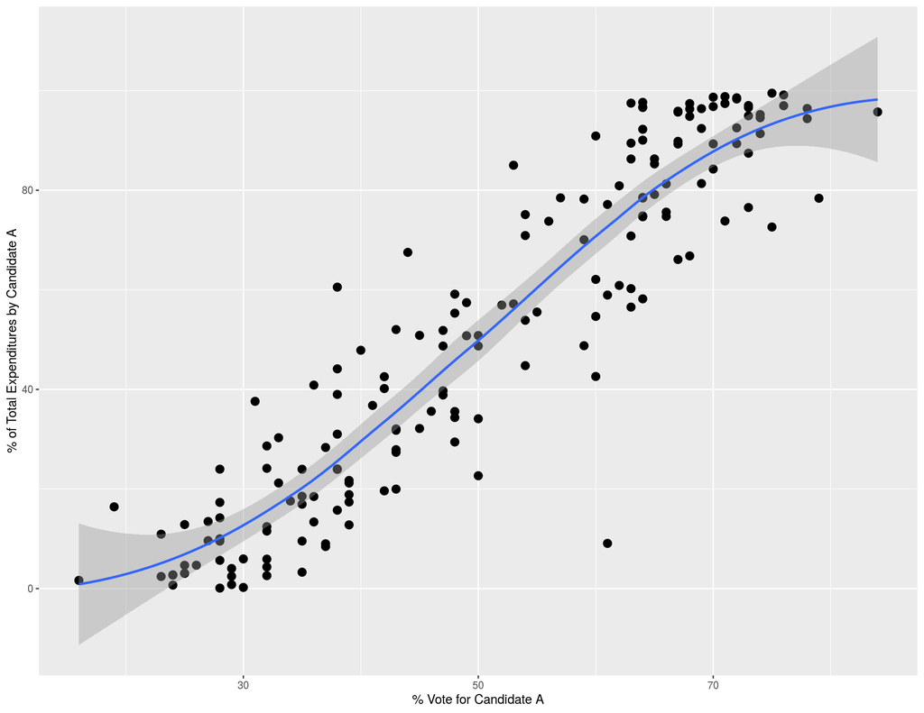

```r
ggplot(data = vote1,
       mapping = aes(x = voteA, y = shareA))+
  geom_point(size = 3) + geom_smooth() +
  labs(x = "% Vote for Candidate A", y = "% of Total Expenditures by Candidate A")
```

```r
expand_limits(x=c(0,100), y=c(0,100))
```

```
## mapping: x = ~x, y = ~y
## geom_blank: na.rm = FALSE
## stat_identity: na.rm = FALSE
## position_identity
```

These are the expected results. Obviously we see that elections more than likely go to the candidates who outspend their opponents, but we also see a lot of elections where that didn’t hold constant. The Loess curve included (using geom_smooth) helps see the total trend, but it’s the points that are far off the trend should garner the most interest.

The upper left and lower right quadrants are the spaces especially worth considering. In the upper left we see races where Candidate A outspent their opponent, but lost. In the lower right we see races where Candidate A spent less than their opponent, but won. It is worth noting at this point that the candidates were selected to be “Candidate A” at random before the election, which is why you’ll see them across the grid, as opposed to being evenly divided up by party or election winner.

One way we could further examine this data is by creating a new column of information. We’ll use the difference of voting percentage versus expenditure percentage to create a new variable called vote differential.

```r
vote1$VoteDif <- (vote1$voteA-vote1$shareA)
```

The first way we’ll use vote differential is to view it against total vote percentage.

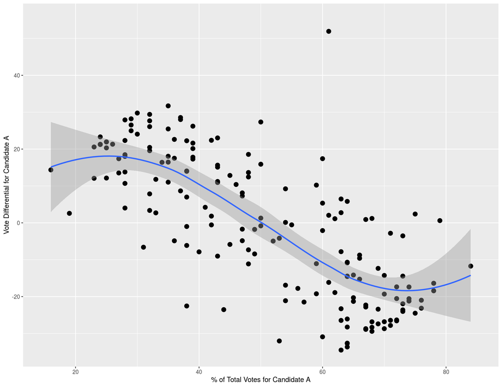

```r
ggplot(data = vote1,
       mapping = aes(x = voteA, y = VoteDif))+
  geom_point(size = 3) +
  geom_smooth() +
  labs(x = "% of Total Votes for Candidate A", y = "Vote Differential for Candidate A")+
  expand_limits(x=c(15,85), y=c(0,55))
```

We see a cluster of candidates in the upper left who likely weren’t viable candidates. They didn’t have a lot of money to put into the campaign and more than likely got their votes from strong party supporters, so while they had a high vote differential, they received well below 50% of the total vote. In the bottom right we see a group of candidates who heavily outspent their opponents and won a high percentage of the vote. These were likely incumbents or candidates that already had a base of strong support, such as the mayor of a large city or a state office holder, who had a lot of resources to pull from in the election. Again, looking for those efficient campaigns to specifically consider, we see our target quadrants have flipped, but they help to further highlight those elections wher Candidate A either spent more per vote and lost, or spent less and won.

More data, however, is needed be added to this graph to assist our reading of the data. We’ll add in total amount spent, as that can help us understand the real dollars being used, as opposed to a comparison against dollars spent by both candidates.

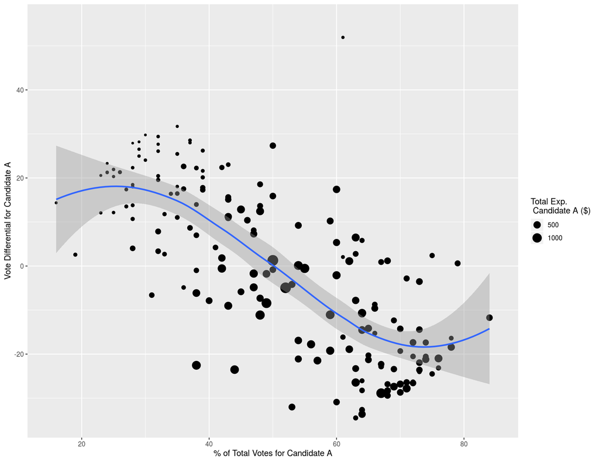

```r
ggplot(data = vote1,
       mapping = aes(x = voteA, y = VoteDif))+
  geom_point(aes(size = vote1$expendA)) +
  geom_smooth() +
  labs(x = "% of Total Votes for Candidate A", y = "Vote Differential for Candidate A", size = ("Total Exp. \n Candidate A ($)"))+
  expand_limits(x=c(15,85), y=c(0,55))
```

This is helpful, but it places emphasis on the races where Candidate A spent a larger amount than their opponent. We’ll reverse the plotting of the expenditures by Candidate A to dial in on those highly efficient campaigns.

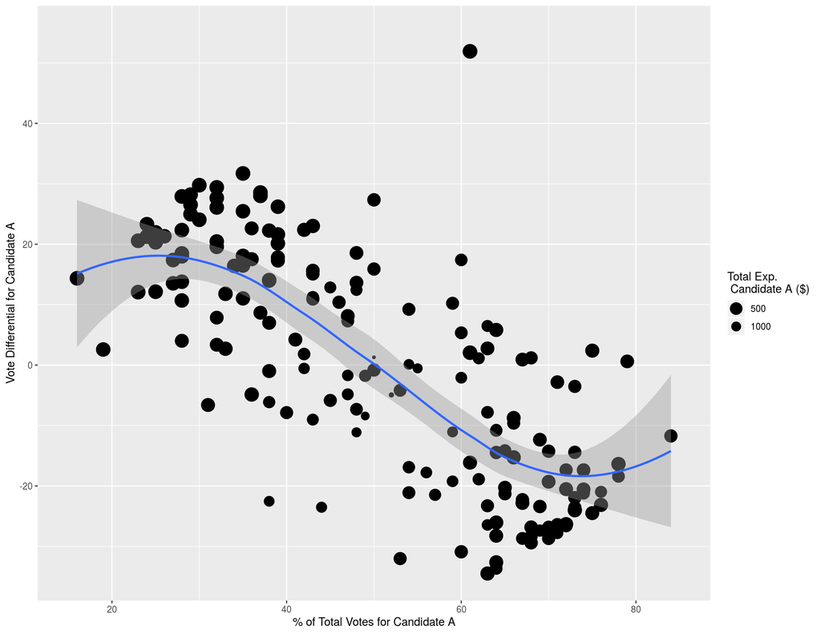

```r
ggplot(data = vote1,
       mapping = aes(x = voteA, y = VoteDif))+
  geom_point(aes(size = vote1$expendA)) +
  scale_size(trans = 'reverse') +
  geom_smooth() +
  labs(x = "% of Total Votes for Candidate A", y = "Vote Differential for Candidate A", size = ("Total Exp. \n Candidate A ($)"))+
  expand_limits(x=c(15,85), y=c(0,55))
```

Now we’re seeing some interesting results. These results prove that there are viable campaigns for us to study, campaigns that were within five percentage points of winning while having a vote differential further than 10 points from their opponent, all while having lower total expenditures. However, if we want this to be a tool that is useful to campaigns, we have to change our graph to consider inputs as opposed to outputs.

For this to be a tool for pre-election planning and prediction, as opposed to post-election analysis, we can’t place vote differential or vote total on our axes. Votes are the outcome, and more than 50% is the target of the campaign, but they are not inputs that are within a campaign’s control. To use this as a tool for assisting campaigns in following in the footsteps of winners from similar circumstances we need to set our axes on campaign expenditures. By doing this a campaign can predict the spending of their opponent, and then consider their spending options to attempt to find similar campaigns.

Once those campaigns are found analysis can be done to figure out the ways in which their campaigns were able to succeed. There may be situations in which there are no good options. There will only be a handful of races in which the underdog candidate comes close to a win.

The only way to know is to do the research.

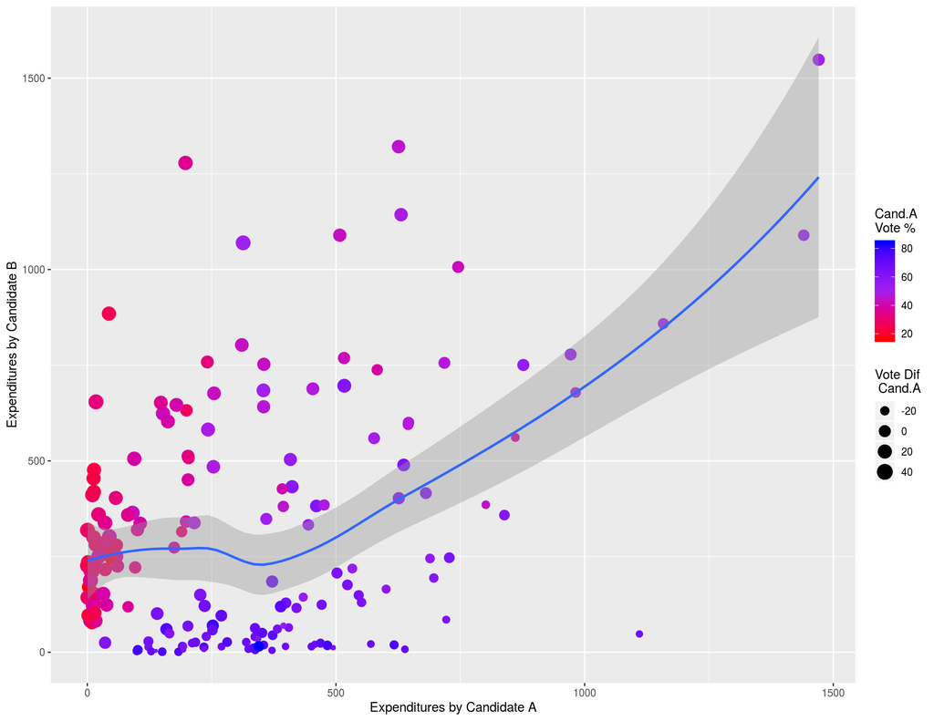

```r
ggplot(data = vote1,
       mapping = aes(x = expendA, y = expendB, color = voteA))+
  geom_point(aes(size = VoteDif)) +
  geom_smooth() +
  scale_color_gradient2(low="red", mid="purple", high="blue", midpoint = 50)+
  labs(x = "Expenditures by Candidate A", y = "Expenditures by Candidate B", size = ("Vote Dif\n Cand.A"), color = "Cand.A\nVote %")+
  expand_limits(x=c(15,85), y=c(0,55))
```

We’re getting closer. Now we’ll add in the State and District data to aid in finding the efficient campaigns.

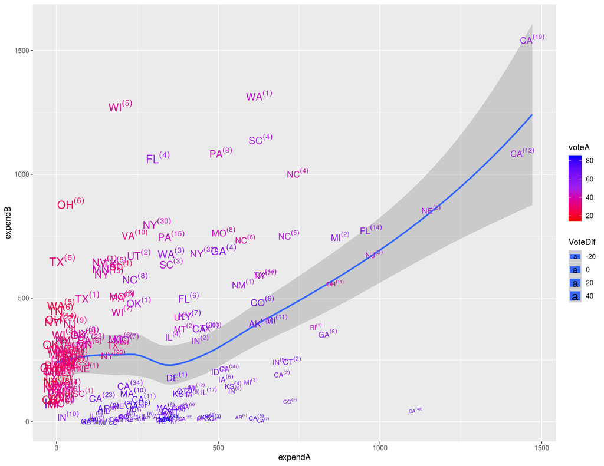

```r
ggplot(data = vote1,
       mapping = aes(x = expendA, y = expendB, color = voteA, size = VoteDif))+
  geom_smooth() +
  scale_color_gradient2(low="red", mid="purple", high="blue", midpoint = 50)+
  labs()+
geom_text(aes(label = paste(state, "^(", district, ")", sep = "")),  parse = TRUE)
```

Now we’ve created a graph with the information plotted in a way that can help us find the efficient campaigns, but they are clouded on the plot by inefficient campaigns with similar expenditure totals. To find these efficient campaigns we’ll have subset our data.

The first subset will be campaigns where Candidate A spent at least 10% less than their opponenet, but within five percentage points of a win. Well call this vote1A, for all the efficient “Candidate As” it will give us.

```r
vote1A <- subset(vote1, shareA <= 45 & voteA >= 45)

head(vote1A, n=25)
```

| state | district | democA | voteA | expendA | expendB | prtystrA | lexpendA | lexpendB | shareA | VoteDif |
| --- | --- | --- | --- | --- | --- | --- | --- | --- | --- | --- |
| FL | 4 | 0 | 50 | 313 | 1.07e+03 | 36 | 5.75 | 6.98 | 22.7 | 27.3 |
| FL | 6 | 0 | 54 | 408 | 504 | 61 | 6.01 | 6.22 | 44.8 | 9.23 |
| GA | 4 | 1 | 60 | 517 | 696 | 41 | 6.25 | 6.55 | 42.6 | 17.4 |
| KY | 2 | 1 | 61 | 8.4 | 84.1 | 41 | 2.13 | 4.43 | 9.08 | 51.9 |
| MO | 7 | 1 | 47 | 215 | 338 | 39 | 5.37 | 5.82 | 38.9 | 8.12 |
| NY | 31 | 1 | 47 | 453 | 688 | 44 | 6.12 | 6.53 | 39.7 | 7.29 |
| NC | 8 | 0 | 48 | 243 | 582 | 62 | 5.49 | 6.37 | 29.4 | 18.6 |
| OK | 1 | 1 | 48 | 254 | 485 | 39 | 5.54 | 6.18 | 34.4 | 13.6 |
| SC | 3 | 0 | 46 | 355 | 641 | 67 | 5.87 | 6.46 | 35.6 | 10.4 |
| SC | 4 | 0 | 48 | 631 | 1.14e+03 | 68 | 6.45 | 7.04 | 35.6 | 12.4 |
| WA | 1 | 1 | 45 | 626 | 1.32e+03 | 51 | 6.44 | 7.19 | 32.1 | 12.9 |
| WA | 3 | 0 | 50 | 354 | 684 | 49 | 5.87 | 6.53 | 34.1 | 15.9 |

We got 12. That’s not a lot, but there will hopefully be as many efficient Candidate Bs as well. We’ll go ahead and plot the efficient As on the graph, which will now be much less crowded. We’ll also remove vote differential, as we know that most of these will an absolute vote differential near or above 10%.

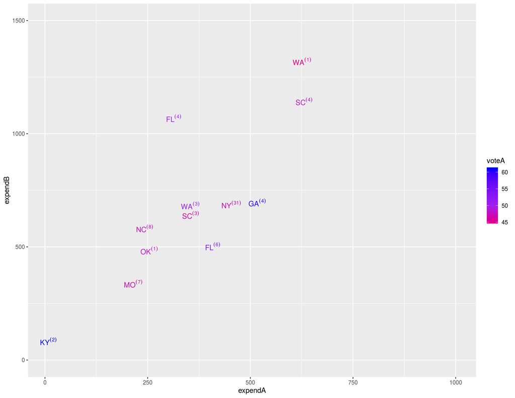

```r
ggplot(data = vote1A,
       mapping = aes(x = expendA, y = expendB, color = voteA))+
  scale_color_gradient2(low="red", mid="purple", high="blue", midpoint = 50)+
  labs()+
  expand_limits(x=c(10,1000), y=c(0,1500))+
geom_text(aes(label = paste(state, "^(", district, ")", sep = "")),  parse = TRUE)
```

Now we’ll set up another subset, using opposite parameters from our previous subset, to find all the places that “Candidate B” spent less than 45% of the total expenditures and received more than 45% of the total vote. We’ll call this group vote1B.

```r
vote1B <- subset(vote1, shareA >= 55 & voteA <= 55)

head(vote1B, n=25)
```

| state | district | democA | voteA | expendA | expendB | prtystrA | lexpendA | lexpendB | shareA | VoteDif |
| --- | --- | --- | --- | --- | --- | --- | --- | --- | --- | --- |
| CA | 12 | 0 | 52 | 1.44e+03 | 1.09e+03 | 49 | 7.27 | 6.99 | 56.9 | -4.94 |
| CA | 36 | 1 | 54 | 533 | 219 | 47 | 6.28 | 5.39 | 70.9 | -16.9 |
| FL | 14 | 1 | 55 | 972 | 778 | 47 | 6.88 | 6.66 | 55.5 | -0.54 |
| IL | 21 | 1 | 53 | 394 | 69.5 | 54 | 5.98 | 4.24 | 85 | -32 |
| IN | 2 | 1 | 53 | 444 | 333 | 35 | 6.1 | 5.81 | 57.2 | -4.17 |
| MI | 12 | 1 | 54 | 434 | 144 | 39 | 6.07 | 4.97 | 75.1 | -21.1 |
| NE | 2 | 0 | 49 | 1.16e+03 | 859 | 58 | 7.05 | 6.76 | 57.4 | -8.42 |
| NJ | 3 | 0 | 48 | 982 | 679 | 63 | 6.89 | 6.52 | 59.1 | -11.1 |
| OH | 11 | 0 | 38 | 861 | 561 | 56 | 6.76 | 6.33 | 60.5 | -22.5 |
| RI | 1 | 1 | 44 | 801 | 385 | 58 | 6.69 | 5.95 | 67.5 | -23.5 |
| TX | 13 | 0 | 48 | 476 | 385 | 64 | 6.17 | 5.95 | 55.3 | -7.31 |

While it would have been great to see more than 11 total races that fit these parameters, giving us a larger sample to observe, the fact that vote1A and vote1B have nearly identical observations means that the randomization of data collection was probably done well.

We’ll plot vote1B on the expenditures graph as well.

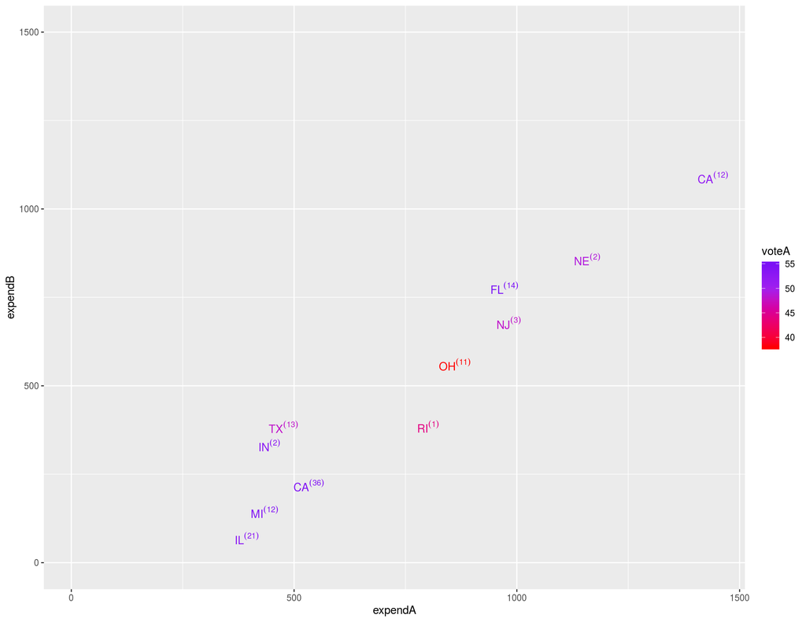

```r
ggplot(data = vote1B,
       mapping = aes(x = expendA, y = expendB, color = voteA))+
  scale_color_gradient2(low="red", mid="purple", high="blue", midpoint = 50)+
  labs()+
  expand_limits(x=c(10,1000), y=c(0,1500))+
geom_text(aes(label = paste(state, "^(", district, ")", sep = "")),  parse = TRUE)
```

Finally, we want to view all of our efficient campaigns together, so we’ll merge the data together for form vote1AB.

```r
vote1AB <- full_join(vote1A, vote1B)
```

[output not shown]

```r
head(vote1AB, n=25)
```

| state | district | democA | voteA | expendA | expendB | prtystrA | lexpendA | lexpendB | shareA | VoteDif |
| --- | --- | --- | --- | --- | --- | --- | --- | --- | --- | --- |
| FL | 4 | 0 | 50 | 313 | 1.07e+03 | 36 | 5.75 | 6.98 | 22.7 | 27.3 |
| FL | 6 | 0 | 54 | 408 | 504 | 61 | 6.01 | 6.22 | 44.8 | 9.23 |
| GA | 4 | 1 | 60 | 517 | 696 | 41 | 6.25 | 6.55 | 42.6 | 17.4 |
| KY | 2 | 1 | 61 | 8.4 | 84.1 | 41 | 2.13 | 4.43 | 9.08 | 51.9 |
| MO | 7 | 1 | 47 | 215 | 338 | 39 | 5.37 | 5.82 | 38.9 | 8.12 |
| NY | 31 | 1 | 47 | 453 | 688 | 44 | 6.12 | 6.53 | 39.7 | 7.29 |
| NC | 8 | 0 | 48 | 243 | 582 | 62 | 5.49 | 6.37 | 29.4 | 18.6 |
| OK | 1 | 1 | 48 | 254 | 485 | 39 | 5.54 | 6.18 | 34.4 | 13.6 |
| SC | 3 | 0 | 46 | 355 | 641 | 67 | 5.87 | 6.46 | 35.6 | 10.4 |
| SC | 4 | 0 | 48 | 631 | 1.14e+03 | 68 | 6.45 | 7.04 | 35.6 | 12.4 |
| WA | 1 | 1 | 45 | 626 | 1.32e+03 | 51 | 6.44 | 7.19 | 32.1 | 12.9 |
| WA | 3 | 0 | 50 | 354 | 684 | 49 | 5.87 | 6.53 | 34.1 | 15.9 |
| CA | 12 | 0 | 52 | 1.44e+03 | 1.09e+03 | 49 | 7.27 | 6.99 | 56.9 | -4.94 |
| CA | 36 | 1 | 54 | 533 | 219 | 47 | 6.28 | 5.39 | 70.9 | -16.9 |
| FL | 14 | 1 | 55 | 972 | 778 | 47 | 6.88 | 6.66 | 55.5 | -0.54 |
| IL | 21 | 1 | 53 | 394 | 69.5 | 54 | 5.98 | 4.24 | 85 | -32 |
| IN | 2 | 1 | 53 | 444 | 333 | 35 | 6.1 | 5.81 | 57.2 | -4.17 |
| MI | 12 | 1 | 54 | 434 | 144 | 39 | 6.07 | 4.97 | 75.1 | -21.1 |
| NE | 2 | 0 | 49 | 1.16e+03 | 859 | 58 | 7.05 | 6.76 | 57.4 | -8.42 |
| NJ | 3 | 0 | 48 | 982 | 679 | 63 | 6.89 | 6.52 | 59.1 | -11.1 |
| OH | 11 | 0 | 38 | 861 | 561 | 56 | 6.76 | 6.33 | 60.5 | -22.5 |
| RI | 1 | 1 | 44 | 801 | 385 | 58 | 6.69 | 5.95 | 67.5 | -23.5 |
| TX | 13 | 0 | 48 | 476 | 385 | 64 | 6.17 | 5.95 | 55.3 | -7.31 |

We got the expected 23 observations, and all of our rows are intact, so our merge seemed to work out well. Now we’ll plot them on our expenditures graph that will allow candidates and their teams to find other efficient campaigns to research in an effort to compete in an election.

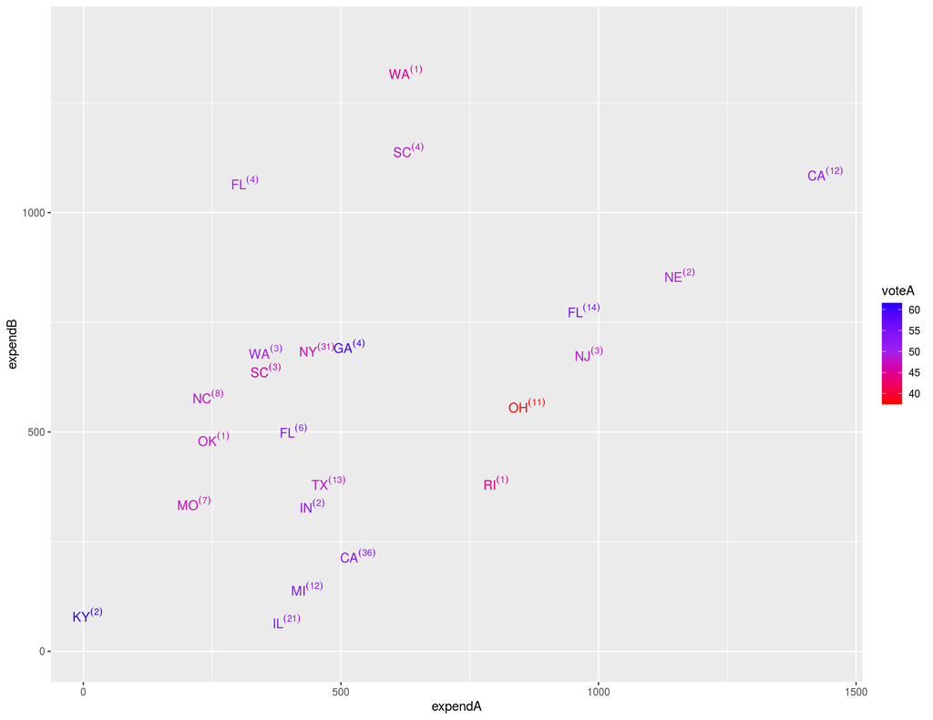

```r
ggplot(data = vote1AB,
       mapping = aes(x = expendA, y = expendB, color = voteA))+
  scale_color_gradient2(low="red", mid="purple", high="blue", midpoint = 50)+
  labs()+
  expand_limits(x=c(10,1000), y=c(0,1400))+
geom_text(aes(label = paste(state, "^(", district, ")", sep = "")),  parse = TRUE)
```

In an effort to double check our data we’ll reset it within the previous plot of vote differential versus total vote received.

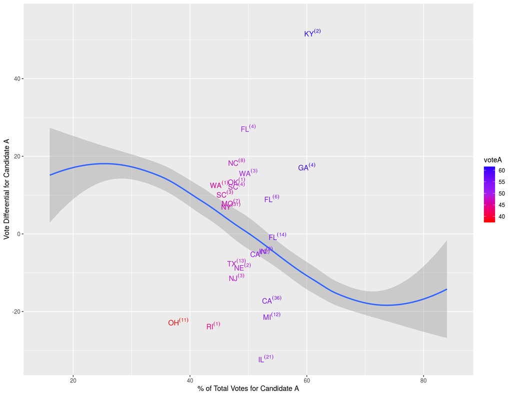

```r
ggplot(data = vote1AB,
       mapping = aes(x = voteA, y = VoteDif, color = voteA))+
  scale_color_gradient2(low="red", mid="purple", high="blue", midpoint = 50)+
  scale_size(trans = 'reverse') +
  geom_smooth(data = vote1) +
  labs(x = "% of Total Votes for Candidate A", y = "Vote Differential for Candidate A", size = ("Total Exp. \n Candidate A ($)"))+
  expand_limits(x=c(15,85), y=c(0,55))+
  geom_text(aes(label = paste(state, "^(", district, ")", sep = "")),  parse = TRUE)
```

For the most part our data points fall in the expected range and this tool can be seen as an option for preliminary research on how to run an efficient campaign.

He received the Presidential Citizens Medal in March of 1994, just weeks before his death.

Kentucky’s 2nd district has not unseat an incumbent for reelection since 1884.